# first work

## Descriptive plot to get to know data

### Tomb parameter

Clean the data:

- delete single entries for T46, T56, T62
- create entries for them as 1 tomb but with difference MNIs (as project partner wants)
- delete irrelevant tombs (only Amfissa, and Elateia T31, T36, T46, T50, T56, T62, T67)

```r
tomb_parameter <- read_excel("Data/raw/Statistics project LMU_tomb parameters_Irene Hoegner_new.xlsx", range = "A2:N12")
combined_tombs <- tomb_parameter |> slice(rep(10, 4)) |> mutate(
  "MNI (minimum number of individuals)" = c(250, 300, 350, 400),
  "percentage of successful samples" = `TWIST capture samples included in kinship analysis` / `MNI (minimum number of individuals)`,
  `...1` = paste("Elateia T 46,56,62 (MNI ", c(250, 300, 350, 400), ")", sep = ""))
tomb_parameter <- rbind(tomb_parameter, combined_tombs)
tomb_parameter <- tomb_parameter |> rename(Tomb = 1, MNI = 2, `analysed individuals` = 12) |>
  slice(-c(4, 5, 7, 8, 10)) |> mutate(MNI = as.integer(MNI))
tomb_parameter
```

```
## # A tibble: 9 × 14
##   Tomb                         MNI original number of s…¹ same individual samp…²
##   <chr>                      <int>                  <dbl>                  <dbl>
## 1 Amfissa tholos               110                    165                      2
## 2 Elateia T31                   26                     21                      0
## 3 Elateia T36                   48                     33                      0
## 4 Elateia T50                   64                     77                      1
## 5 Elateia T67                   NA                     21                      0
## 6 Elateia T 46,56,62 (MNI 2…   250                    337                      9
## 7 Elateia T 46,56,62 (MNI 3…   300                    337                      9
## 8 Elateia T 46,56,62 (MNI 3…   350                    337                      9
## 9 Elateia T 46,56,62 (MNI 4…   400                    337                      9
## # ℹ abbreviated names: ¹`original number of samples`,
## #   ²`same individual sampled twice`
## # ℹ 10 more variables: `max number of individuals` <dbl>,
## #   `petrous bones` <dbl>, teeth <dbl>, `talus/phalanx` <dbl>, other <dbl>,
## #   control <lgl>, `TWIST capture samples included in kinship analysis` <dbl>,
## #   `analysed individuals` <dbl>, `length of use of tomb` <chr>,
## #   `percentage of successful samples` <dbl>
```

The important info in this dataset: “MNI” and “after merging samples from same individual” (**minimum # individuals** vs **actual successful analysed # individual**), since if we don’t consider the ratio between them, the result could be bias.

Therefore I create plots of absolute and relative relation of those numbers for every tombs:

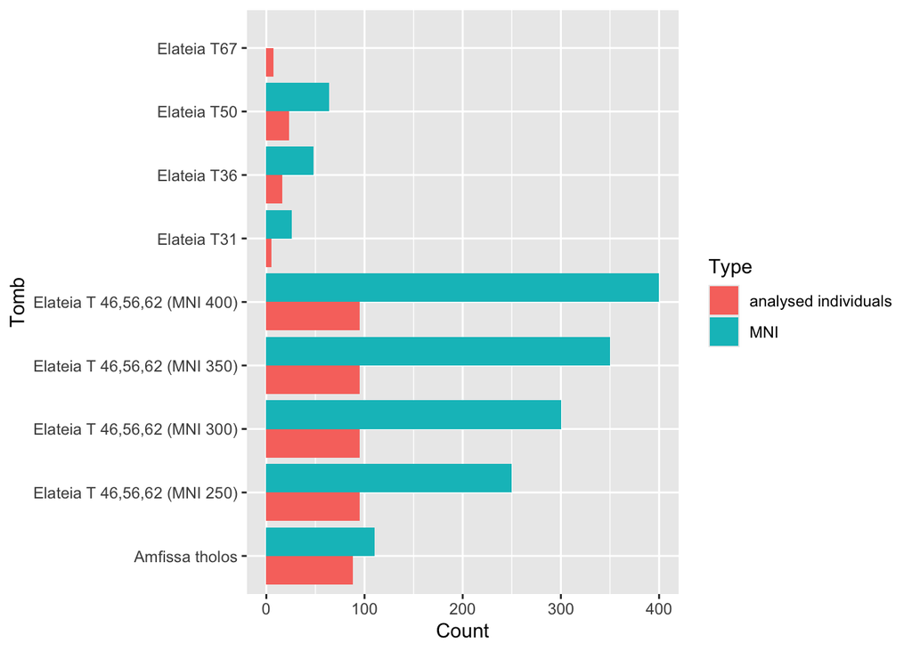

```r
# Absolute plot
df_long <- pivot_longer(tomb_parameter, cols = c(MNI, `analysed individuals`),
                        names_to = "Type", values_to = "Count")
ggplot(df_long, aes(x = Tomb, y = Count, fill = Type)) +
  geom_bar(stat = "identity", position = "dodge") +
  coord_flip()
```

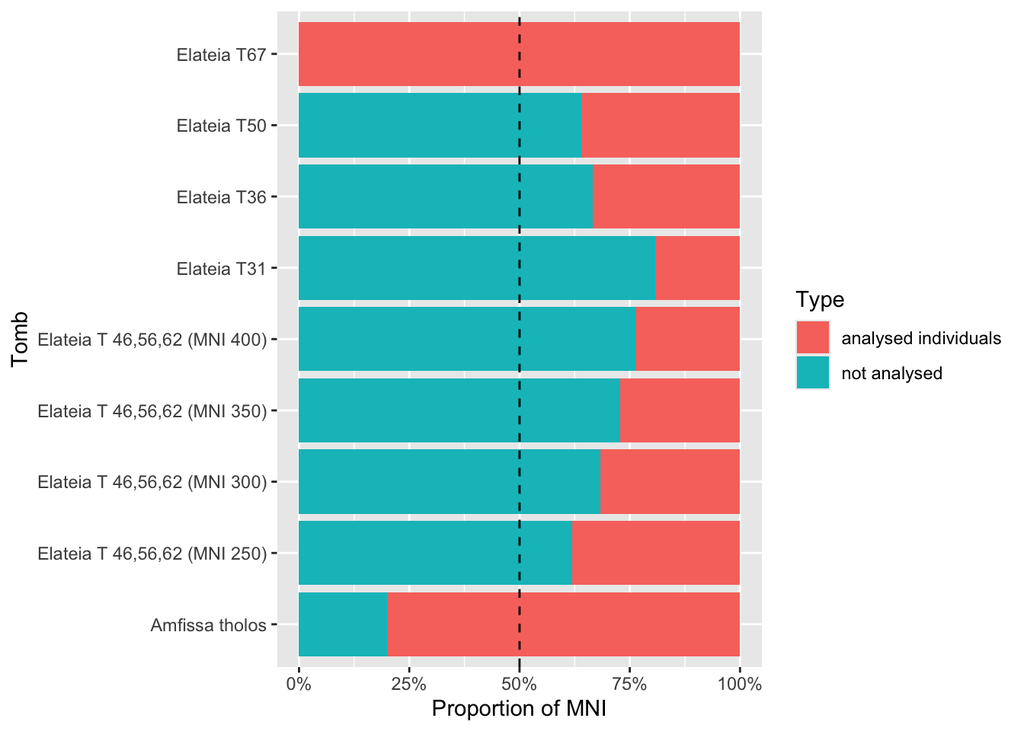

```r
tomb_parameter |>
  mutate(`not analysed` = MNI - `analysed individuals`) |>
  pivot_longer(cols = c(`not analysed`, `analysed individuals`),
               names_to = "Type", values_to = "Count") |>
  ggplot(aes(x = Tomb, y = Count, fill = Type)) +
  geom_bar(stat = "identity", position = "fill") +
  ylab("Proportion of MNI") +
  scale_y_continuous(labels = scales::percent) +
  geom_hline(yintercept = 0.5, linetype = "dashed") +
  coord_flip()
```

Comment:

### Individual metadata

Basic descriptive plots for basic information

Note: filter out Lapoutsi, filter out irrelevant tombs, treating 46 56 62 as one.

#### Sex

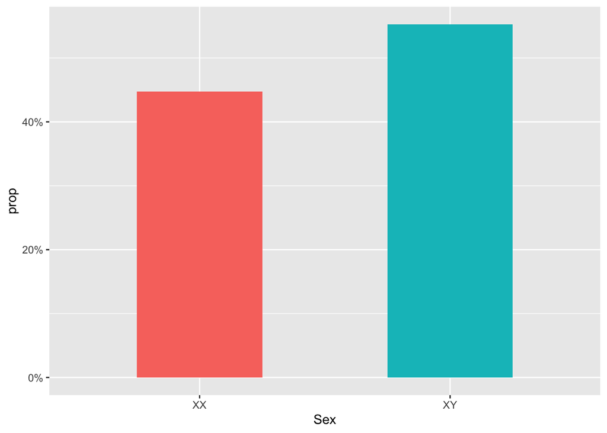

```r
individual_metadata <- read_excel("Data/raw/Statistics project LMU_individuals metadata_Irene Hoegner.xlsx")
individual_metadata <- individual_metadata |>
  filter(Site != "Lapoutsi", Tomb %in% c("Amfissa tholos", "Tomb 31", "Tomb 36", "Tomb 46", "Tomb 50", "Tomb 56", "Tomb 62", "Tomb 67")) |>
  mutate(Tomb = ifelse(Tomb %in% c("Tomb 46", "Tomb 56", "Tomb 62"), "Tomb 46 56 62", Tomb))

individual_metadata |> ggplot(mapping = aes(x = Sex, fill = Sex, y = after_stat(prop))) +
  geom_bar(aes(y = after_stat(count / sum(count))), width = 0.5) +
  theme(legend.position = "none") +
  scale_y_continuous(labels = scales::percent)
```

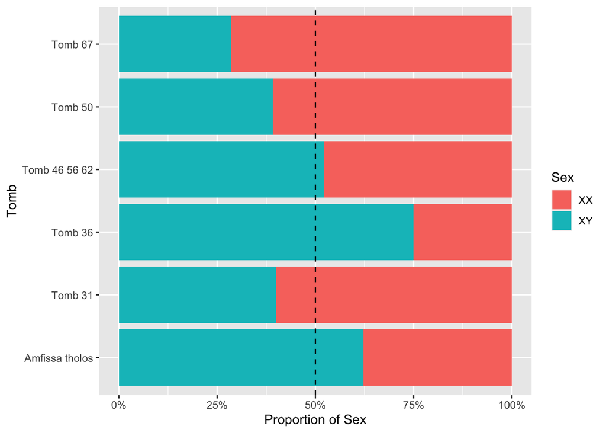

```r
individual_metadata |>
  count(Tomb, Sex) |>
  group_by(Tomb) |>
  mutate(prop = n / sum(n)) |>
  ggplot(aes(x = Tomb, y = prop, fill = Sex)) +
  geom_bar(stat = "identity", position = "fill") +
  scale_y_continuous(labels = scales::percent) +
  ylab("Proportion of Sex") +
  geom_hline(yintercept = 0.5, linetype = "dashed") +
  coord_flip()
```

Comment:

- Overall there are more analysed male then female
- Different ratio of male and female in each tomb separately
- Just a hypothesis: some tombs might represent family (balanced sex ratio, more related), some tombs use for male dominated group like warrior,… (more male, less related)? (but maybe its not our job to give out specific comment like this)

#### Skeletal element

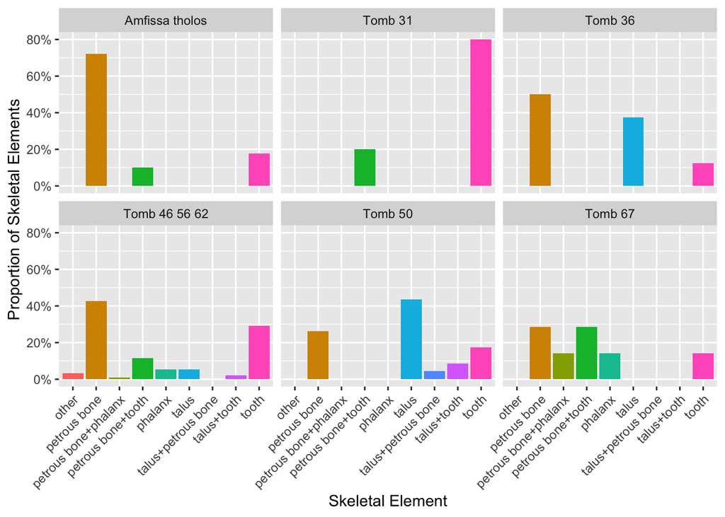

```r
individual_metadata |>
  count(Tomb, `Skeletal element`) |>
  group_by(Tomb) |>
  mutate(prop = n / sum(n)) |>
  ggplot(aes(x = `Skeletal element`, y = prop, fill = `Skeletal element`)) +
  geom_bar(stat = "identity") +
  facet_wrap(~ Tomb) +
  scale_y_continuous(labels = scales::percent) +
  theme(axis.text.x = element_text(angle = 45, hjust = 1),
        legend.position = "none") +
  ylab("Proportion of Skeletal Elements") +
  xlab("Skeletal Element")
```

Comment:

- As explained, petrous bone yields the best preservation of aDNA. Therefore tombs with many petrous bone sample may appear more related solely because of the good aDNA preservation. Some might appear less related just because we have less data / less qualified preservation of aDNA.
- **For further improvement**: clean data so that the skeletal element counts every piece of bone seperately. Eg. instead of **1 talus+tooth** we have **1 talus and 1 tooth**. So that the information dont overlapp.

#### Age estimation

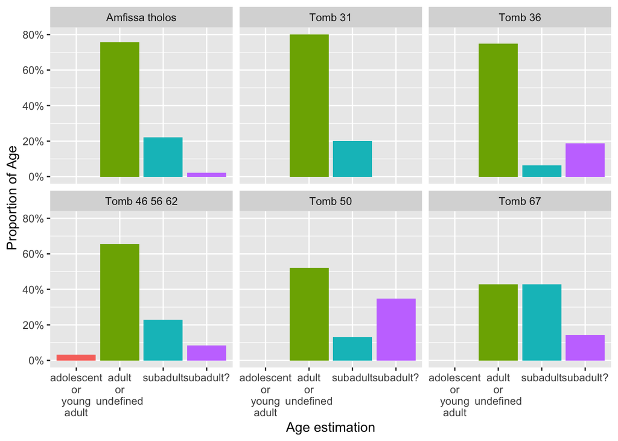

```r
individual_metadata |>
  count(Tomb, `Age estimation`) |>
  group_by(Tomb) |>
  mutate(prop = n / sum(n)) |>
  ggplot(aes(x = `Age estimation`, y = prop, fill = `Age estimation`)) +
  geom_bar(stat = "identity") +
  facet_wrap(~ Tomb) +
  scale_y_continuous(labels = scales::percent) +
  theme(legend.position = "none") +
  scale_x_discrete(labels = label_wrap(7)) +
  ylab("Proportion of Age") +
  xlab("Age estimation")
```

Comment:

- “adult or undefined” is very confusing?? is it high because they are adult or because we dont know??
- adult is more likely to die and get buried (obviously)
- subadult????????
- we could consider it because “age” may correlate with DNA preservation? juveniles may have more fragile bones and therefore could not be analysed, not because they were not buried there?

### Kinship result

Clean data:

- Re-label relationship under threshold
- Extract Individual ID to merge
- Merge together with (original) “Individual metadata” to get the tomb
- Filter out Lapoutsi
- Delete irrelevant tombs + group tombs

```r
kinship_result <- read_excel("Data/raw/Statistics project LMU_READv2 kinship results_Irene Hoegner.xlsx")
og_individual_metadata <- read_excel("Data/raw/Statistics project LMU_individuals metadata_Irene Hoegner.xlsx")

kinship_result <- kinship_result |>
  mutate(Rel = case_when(
    Rel == "First Degree"  & OverlapNSNPs < 500   ~ "Uncertain",
    Rel == "Second Degree" & OverlapNSNPs < 2000  ~ "Uncertain",
    Rel == "Third Degree"  & OverlapNSNPs < 15000 ~ "Uncertain",
    TRUE ~ Rel
  ),
  "Individual1 ID" = substr(Ind1, 1, 6),
  "Individual2 ID" = substr(Ind2, 1, 6)) |>
  left_join(og_individual_metadata, by = c("Individual1 ID" = "Individual ID")) |>
  rename(Tomb1 = Tomb) |>
  left_join(og_individual_metadata, by = c("Individual2 ID" = "Individual ID")) |>
  rename(Tomb2 = Tomb) |>
  select(names(kinship_result), Tomb1, Tomb2) |>
  mutate(
    "Individual1 ID" = substr(Ind1, 1, 6),
    "Individual2 ID" = substr(Ind2, 1, 6)
  ) |>
  filter(!startsWith(`Ind1`, "LPS") & !startsWith(`Ind2`, "LPS"),
         Tomb1 %in% c("Amfissa tholos", "Tomb 31", "Tomb 36", "Tomb 46", "Tomb 50", "Tomb 56", "Tomb 62", "Tomb 67"),
         Tomb2 %in% c("Amfissa tholos", "Tomb 31", "Tomb 36", "Tomb 46", "Tomb 50", "Tomb 56", "Tomb 62", "Tomb 67")) |>
  mutate(
    Tomb1 = ifelse(Tomb1 %in% c("Tomb 46", "Tomb 56", "Tomb 62"), "Tomb 46 56 62", Tomb1),
    Tomb2 = ifelse(Tomb2 %in% c("Tomb 46", "Tomb 56", "Tomb 62"), "Tomb 46 56 62", Tomb2)
  )

# COUNT PAIRS
count_pairs <- kinship_result |> group_by(Tomb1, Tomb2, Rel) |> summarize(num_pairs = n())
internal_relation <- count_pairs[count_pairs$Tomb1 == count_pairs$Tomb2, ]  # 2 Inds inside same tomb
internal_relation
```

```
## # A tibble: 32 × 4
## # Groups:   Tomb1, Tomb2 [6]
##    Tomb1          Tomb2          Rel                                   num_pairs
##    <chr>          <chr>          <chr>                                     <int>
##  1 Amfissa tholos Amfissa tholos First Degree                                 24
##  2 Amfissa tholos Amfissa tholos IdenticalTwins/SameIndividual                12
##  3 Amfissa tholos Amfissa tholos Second Degree                                22
##  4 Amfissa tholos Amfissa tholos Third Degree                                 23
##  5 Amfissa tholos Amfissa tholos Uncertain                                   237
##  6 Amfissa tholos Amfissa tholos Unrelated                                  3378
##  7 Amfissa tholos Amfissa tholos Unrelated/Consistent with Third Degr…       309
##  8 Tomb 31        Tomb 31        Second Degree                                 1
##  9 Tomb 31        Tomb 31        Unrelated                                     9
## 10 Tomb 36        Tomb 36        First Degree                                  9
## # ℹ 22 more rows
```

```r
external_relation <- count_pairs[count_pairs$Tomb1 != count_pairs$Tomb2, ]  # 2 Inds inside different tomb
external_relation
```

```
## # A tibble: 109 × 4
## # Groups:   Tomb1, Tomb2 [30]
##    Tomb1          Tomb2         Rel                                    num_pairs
##    <chr>          <chr>         <chr>                                      <int>
##  1 Amfissa tholos Tomb 31       Third Degree                                   1
##  2 Amfissa tholos Tomb 31       Unrelated                                    295
##  3 Amfissa tholos Tomb 31       Unrelated/Consistent with Third Degree         3
##  4 Amfissa tholos Tomb 36       First Degree                                   1
##  5 Amfissa tholos Tomb 36       Uncertain                                     15
##  6 Amfissa tholos Tomb 36       Unrelated                                   1020
##  7 Amfissa tholos Tomb 36       Unrelated/Consistent with Third Degree        42
##  8 Amfissa tholos Tomb 46 56 62 IdenticalTwins/SameIndividual                 19
##  9 Amfissa tholos Tomb 46 56 62 Second Degree                                  7
## 10 Amfissa tholos Tomb 46 56 62 Third Degree                                   7
## # ℹ 99 more rows
```

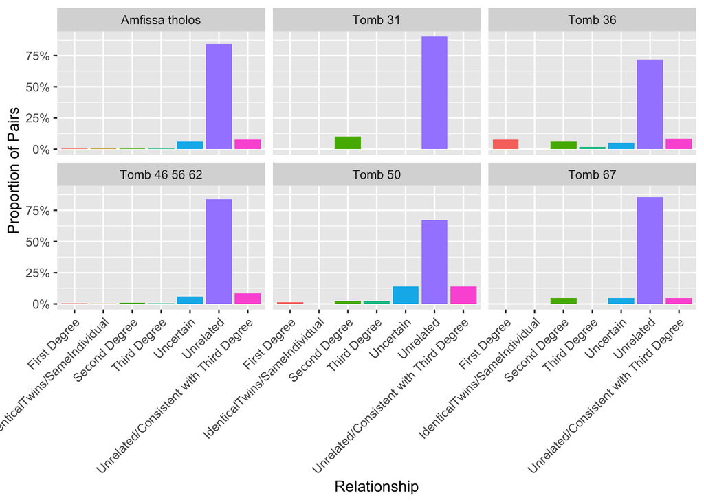

```r
internal_relation |>
  group_by(Tomb1) |>
  mutate(prop = num_pairs / sum(num_pairs)) |>
  ggplot(aes(x = Rel, y = prop, fill = Rel)) +
  geom_bar(stat = "identity") +
  facet_wrap(~ Tomb1) +
  theme(legend.position = "none",
        axis.text.x = element_text(angle = 45, hjust = 1)) +
  scale_y_continuous(labels = scales::percent) +
  ylab("Proportion of Pairs") +
  xlab("Relationship")
```

Comment:

- Very low related ratio
- Improvement: Devide binary into “Related” and “Not related”

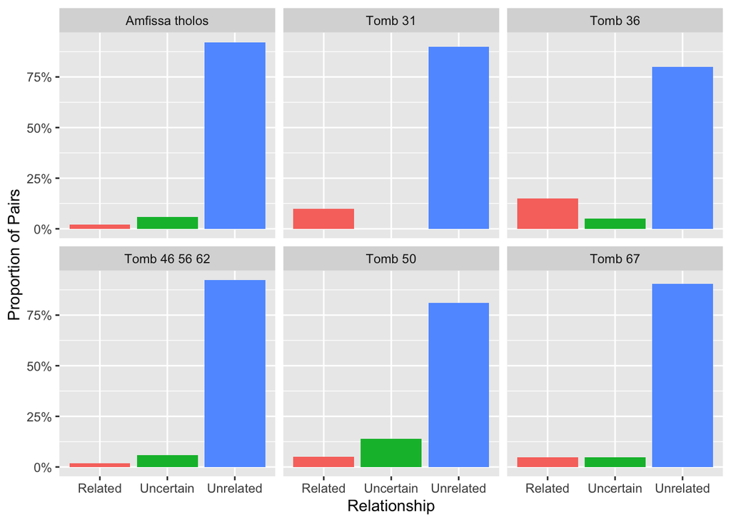

```r
binary_kr <- internal_relation |>
  mutate(Rel_group = case_when(
    Rel %in% c("First Degree", "IdenticalTwins/SameIndividual", "Second Degree", "Third Degree") ~ "Related",
    Rel == "Uncertain" ~ "Uncertain",
    Rel %in% c("Unrelated", "Unrelated/Consistent with Third Degree") ~ "Unrelated"
  ))

binary_kr |>
  group_by(Tomb1) |>
  mutate(prop = num_pairs / sum(num_pairs)) |>
  ggplot(aes(x = Rel_group, y = prop, fill = Rel_group)) +
  geom_bar(stat = "identity") +
  facet_wrap(~ Tomb1) +
  theme(legend.position = "none") +
  scale_y_continuous(labels = scales::percent) +
  ylab("Proportion of Pairs") +
  xlab("Relationship")
```